# Lesson 07: Sampling and Sampling Distributions

22 July, 2018

## 1.) Uniform Sampling

Use the uniform distribution over the interval 0 to 1.

- Draw 100 random samples of size 10.
- Calculate the means for each sample.
- Using the 100 mean values plot a histogram.
- Repeat with 100 random samples of size 50.
- Repeat with 100 samples of size 500.
- Present the three histograms using par().

Calculate the variance of each histogram and compare to the original uniform distribution. What do you conclude?

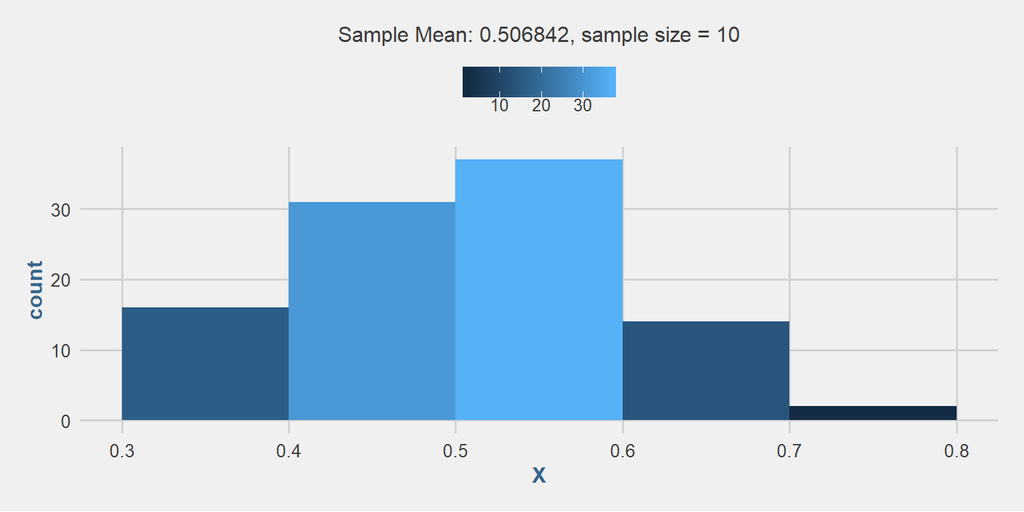

```r
unif_means <- function(n, s) {
    sapply(seq(from = 1, to = n, by = 1), FUN = function(x) {
        mean( runif(s, 0, 1) )
    })
}

plot_means <- function(m, s) {
    ggplot(data.table(X = m), mapping = aes(x = X, fill = ..count..)) +
        geom_histogram(breaks = pretty(m)) +
        labs(subtitle = sprintf("Sample Mean: %.6f, sample size = %.0f", mean(m), s)) +
        theme()
}

s <- 10
m10 <- unif_means(100, s)
plot_means(m10, s)
```

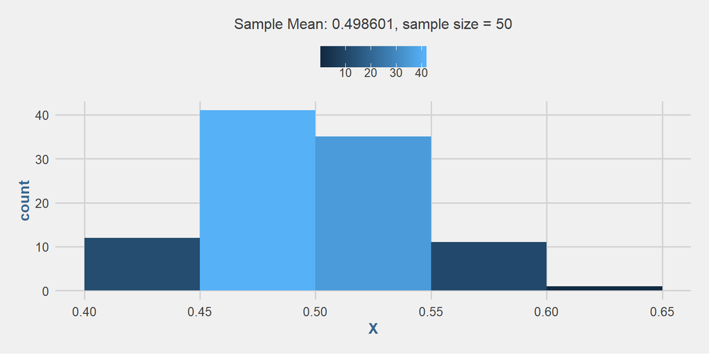

```r
s <- 50
m50 <- unif_means(100, s)
plot_means(m50, s)
```

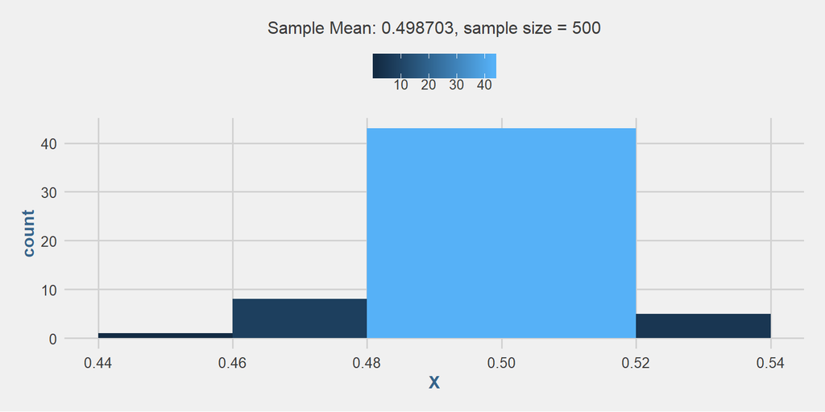

```r
s <- 500

m500 <- unif_means(100, s)
plot_means(m500, s)
```

## 2.) Uniform to Normal

> Using the histogram determined above for samples of size 50, find the quartiles. Using the normal distribution with the true mean and variance for a uniform distribution over the interval 0 to 1, determine the theoretical quartiles for a sample mean from 50 observations. Compare the two sets of quartiles. What do you conclude?

```r
quantile(m50)
```

```
##        0%       25%       50%       75%      100%
## 0.4024304 0.4730777 0.4965171 0.5304040 0.6056936
```

```r
get_true_means <- function(n, u, sd) {
    sapply(seq(from = 1, to = n, by = 1),
        FUN = function(x) {
            mean( rnorm( n, mean = u, sd))
        })
}

quantile(get_true_means(50, .5, sqrt(0.08333333)))
```

```
##        0%       25%       50%       75%      100%
## 0.3933835 0.4620194 0.4968587 0.5181439 0.5940238
```

**Answer:**

> The quantiles are very simlilar. Likely to continue converging as sample sizes increase.

## 3.) Binomial Sampling

> Use the binomial distribution with p = 0.5. Draw 100 random samples of size 10. Calculate the means for each sample. Using the 100 mean values plot a histogram. Repeat with 100 random samples of size 50. Repeat with 100 samples of size 500. Present the three histograms using par(). Calculate the variance of each histogram and compare to the original mean and variance for the binomial. What do you conclude?

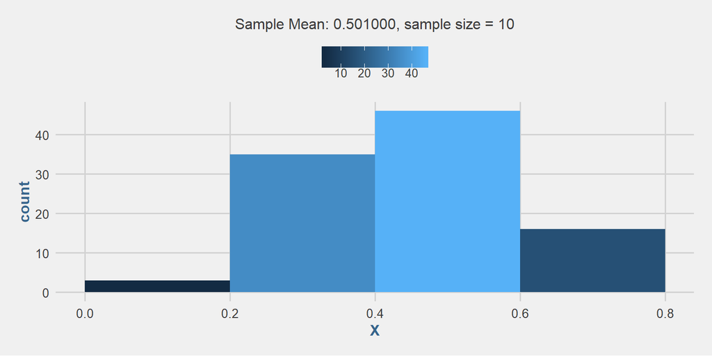

```r
binom_means <- function(n, s, p) {
    sapply(seq(from = 1, to = n, by = 1), FUN = function(x) {
        mean(rbinom(s, 1, p))
    })
}

s <- 10
bm10 <- binom_means(100, s, .5)
plot_means(bm10, s)
```

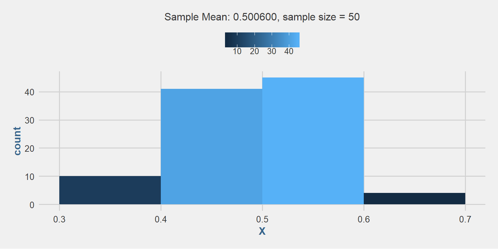

```r
s <- 50
bm50 <- binom_means(100, s, .5)
plot_means(bm50, s)
```

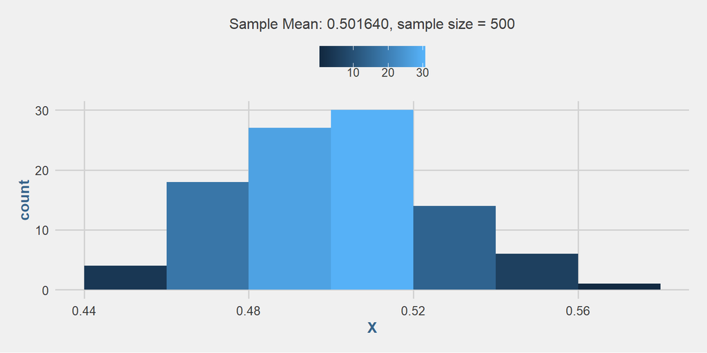

```r
s <- 500
bm500 <- binom_means(100, s, .5)
plot_means(bm500, s)
```

## 4.) Binominal to Normal

> Using the histogram determined above for samples of size 50, find the quartiles. Using the normal distribution with the true mean and variance for a binomial distribution with p = 0.5, determine the theoretical quartiles for a sample mean from 50 observations. Compare the two sets of quartiles. What do you conclude?

```r
quantile(bm50)
```

```
##   0%  25%  50%  75% 100%
## 0.30 0.44 0.50 0.56 0.66
```

```r
quantile(get_true_means(50, .5, sqrt(.25)))
```

```
##        0%       25%       50%       75%      100%
## 0.3470128 0.4482206 0.4994012 0.5419731 0.6240359
```

**Answer:**

> The quantiles are very simlilar. Likely to continue converging as sample sizes increase.

## 5.) Right Skewed Binomial

> Use the binomial distribution with p = 0.1. Draw 100 random samples of size 10. Calculate the means for each sample. Using the 100 mean values plot a histogram. Repeat with 100 random samples of size 50. Repeat with 100 samples of size 500. Present the three histograms using par(). Calculate the variance of each histogram and compare to the original mean and variance for the binomial. What do you conclude?

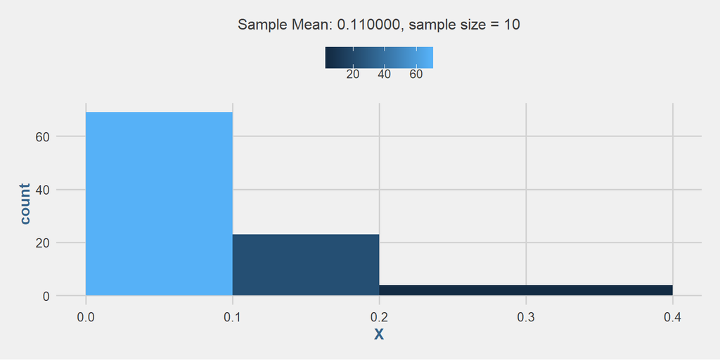

```r
s <- 10
lbm10 <- binom_means(100, s, .1)
plot_means(lbm10, s)
```

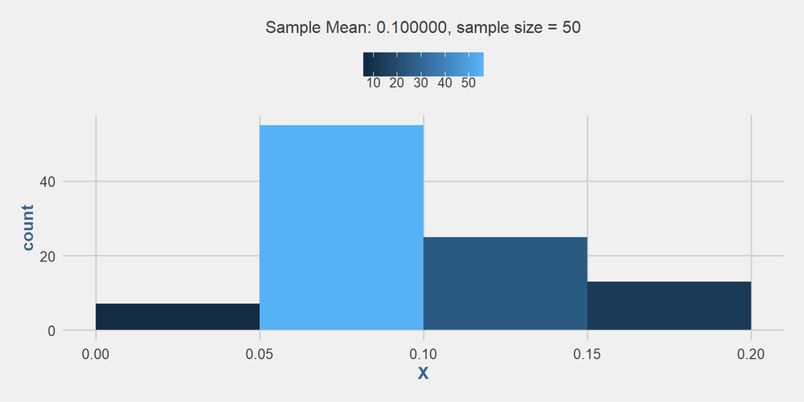

```r
s <- 50
lbm50 <- binom_means(100, s, .1)
plot_means(lbm50, s)
```

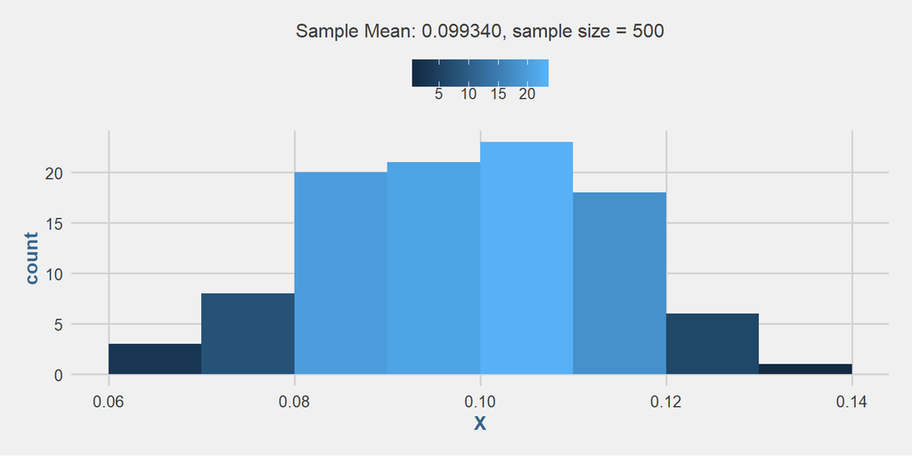

```r
s <- 500
lbm500 <- binom_means(100, s, .1)
plot_means(lbm500, s)
```

## 6.) Right-Skewed Comparision

> Using the histogram determined above for samples of size 50, find the quartiles. Using the normal distribution with the true mean and variance for a binomial distribution with p = 0.1, determine the theoretical quartiles for a sample mean from 50 observations. Compare the two sets of quartiles. What do you conclude?

```r
quantile(lbm50)
```

```
##   0%  25%  50%  75% 100%
## 0.02 0.06 0.10 0.12 0.20
```

```r
quantile(get_true_means(50, .1, sqrt(.09)))
```

```
##           0%          25%          50%          75%         100%
## -0.004429257  0.083909389  0.110778977  0.138885486  0.188703895
```

**Answer:**

> The quantiles are very simlilar. Likely to continue converging as sample sizes increase.